# D21034 - Recommender system

## Name : Srinidhi M

## Roll No: D21034

## Table Of Contents:

- 1.Problem Statement
- 2.Data Description
  - 2.1.Import Libraries
  - 2.2.Load data
- 3.Exploratory Data Analysis
- Approach
- 4.Content Based Movie Recommender System
- 5.User-User Collaborative filtering

# 1.Problem Statement

To build a recommender system that recommends movies based on Genre, IMDB Ratings by using the below two different recommendation techniques

- Content based recommender system
- User-user collaborative filtering recommender system

# 2.Data Description

The dataset contains data from below two files:

- movies.csv
- ratings.csv

The dataset consists of metadata for about 9742 observations of movies listed. The data contains the movies released within the year 1902 and 2018. The main attributes include genre, movieID, rating, userID.

### 2.1.Import Libraries

```python
import pandas as pd
import numpy as np
import matplotlib.pyplot as plt
import re
import seaborn as sns
import datetime
from collections import Counter
import nltk
from sklearn.metrics.pairwise import sigmoid_kernel
```

### 2.2.Load data

```python
movies = pd.read_csv(r"C:\Users\Admin\Documents\Praxis\Term-2\AML\movies.csv")
ratings = pd.read_csv(r"C:\Users\Admin\Documents\Praxis\Term-2\AML\ratings.csv")
```

```python
print(movies.shape)
print(ratings.shape)
```

```
(9742, 3)
(100836, 4)
```

```python
movies.head()
```

|  | movieId | title | genres |
| --- | --- | --- | --- |
| 0 | 1 | Toy Story (1995) | Adventure\|Animation\|Children\|Comedy\|Fantasy |
| 1 | 2 | Jumanji (1995) | Adventure\|Children\|Fantasy |
| 2 | 3 | Grumpier Old Men (1995) | Comedy\|Romance |
| 3 | 4 | Waiting to Exhale (1995) | Comedy\|Drama\|Romance |
| 4 | 5 | Father of the Bride Part II (1995) | Comedy |

```python
ratings.head()
```

|  | userId | movieId | rating | timestamp |
| --- | --- | --- | --- | --- |
| 0 | 1 | 1 | 4.0 | 964982703 |
| 1 | 1 | 3 | 4.0 | 964981247 |
| 2 | 1 | 6 | 4.0 | 964982224 |
| 3 | 1 | 47 | 5.0 | 964983815 |
| 4 | 1 | 50 | 5.0 | 964982931 |

```python
ratings.dtypes
```

```
userId         int64
movieId        int64
rating       float64
timestamp      int64
dtype: object
```

**The timestamp column is seen to have int datatype. It is required to convert them to appropriate datatype**

```python
#Convert the timestamp column to datetime
ratings['timestamp'] = pd.to_datetime(ratings['timestamp'], unit='s')
```

```python
ratings.head()
```

|  | userId | movieId | rating | timestamp |
| --- | --- | --- | --- | --- |
| 0 | 1 | 1 | 4.0 | 2000-07-30 18:45:03 |
| 1 | 1 | 3 | 4.0 | 2000-07-30 18:20:47 |
| 2 | 1 | 6 | 4.0 | 2000-07-30 18:37:04 |
| 3 | 1 | 47 | 5.0 | 2000-07-30 19:03:35 |
| 4 | 1 | 50 | 5.0 | 2000-07-30 18:48:51 |

```python
ratings.dtypes
```

```
userId                int64
movieId               int64
rating              float64
timestamp    datetime64[ns]
dtype: object
```

# 3.Exploratory Data Analysis

```python
#check the number of unique movies
movies['title'].nunique()
```

```
9737
```

**Among the 9742 observations of movies data, 9737 movies are unique**

### Check null values

```python
movies.isnull().sum()
```

```
movieId    0
title      0
genres     0
dtype: int64
```

```python
ratings.isnull().sum()
```

```
userId       0
movieId      0
rating       0
timestamp    0
dtype: int64
```

### Number of movies each user rated

```python
user_movie = pd.DataFrame()    #Creatin a dataframe to store values

#indexing & sorting by userId,counting movies and storing it in a new column name as 'count_of_movies'
user_movie['count_of_movies'] = ratings.groupby(by='userId')['movieId'].count()
```

```python
user_movie.head()
```

| userId | count_of_movies |
| --- | --- |
| 1 | 232 |
| 2 | 29 |
| 3 | 39 |
| 4 | 216 |
| 5 | 44 |

```python
user_movie.describe()
```

|  | count_of_movies |
| --- | --- |
| count | 610.000000 |
| mean | 165.304918 |
| std | 269.480584 |
| min | 20.000000 |
| 25% | 35.000000 |
| 50% | 70.500000 |
| 75% | 168.000000 |
| max | 2698.000000 |

```
[Text(0.5, 1.0, 'Number of movies watched by users')]
```

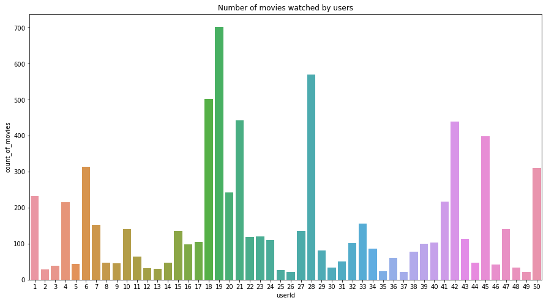

```python
plt.figure(figsize=(15,8))

#visualizing for first 50 users
sns.barplot(x=user_movie.index[:50],y='count_of_movies', data=user_movie.iloc[:50]).set(title='Number of movies watched by users')
```

```python
movie_ratings = pd.DataFrame()
movie_ratings['average_rating'] = ratings.groupby(by='movieId')['rating'].mean()
```

```python
movie_ratings.head()
```

| movieId | average_rating |
| --- | --- |
| 1 | 3.920930 |
| 2 | 3.431818 |
| 3 | 3.259615 |
| 4 | 2.357143 |
| 5 | 3.071429 |

```
[Text(0.5, 1.0, 'Average ratings of movies')]
```

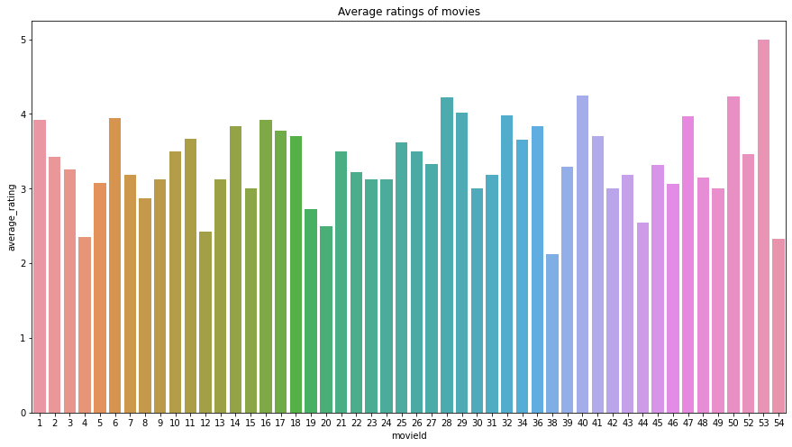

```python
plt.figure(figsize=(15,8))

#visualizing for first 50 users
sns.barplot(x=movie_ratings.index[:50],y='average_rating', data=movie_ratings.iloc[:50]).set(title='Average ratings of movies')
```

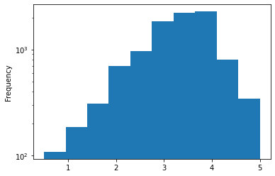

```python
movie_ratings['average_rating'].plot(logy=True, kind='hist')
```

### Top N rated movies

```python
#create a new dataframe and store the sorted 'average_rating' values in descending order
sorted_movie_ratings = movie_ratings.sort_values(by=['average_rating'], ascending=False)
sorted_movie_ratings.head()
```

| movieId | average_rating |
| --- | --- |
| 88448 | 5.0 |
| 100556 | 5.0 |
| 143031 | 5.0 |
| 143511 | 5.0 |
| 143559 | 5.0 |

```python
sorted_movie_ratings.reset_index()
```

|  | movieId | average_rating |
| --- | --- | --- |
| 0 | 88448 | 5.0 |
| 1 | 100556 | 5.0 |
| 2 | 143031 | 5.0 |
| 3 | 143511 | 5.0 |
| 4 | 143559 | 5.0 |
| ... | ... | ... |
| 9719 | 157172 | 0.5 |
| 9720 | 85334 | 0.5 |
| 9721 | 53453 | 0.5 |
| 9722 | 8494 | 0.5 |
| 9723 | 71810 | 0.5 |

9724 rows × 2 columns

```python
#Top 10 movies
sorted_movie_ratings[:10].merge(movies, how='left', on='movieId')
```

|  | movieId | average_rating | title | genres |
| --- | --- | --- | --- | --- |
| 0 | 88448 | 5.0 | Paper Birds (Pájaros de papel) (2010) | Comedy\|Drama |
| 1 | 100556 | 5.0 | Act of Killing, The (2012) | Documentary |
| 2 | 143031 | 5.0 | Jump In! (2007) | Comedy\|Drama\|Romance |
| 3 | 143511 | 5.0 | Human (2015) | Documentary |
| 4 | 143559 | 5.0 | L.A. Slasher (2015) | Comedy\|Crime\|Fantasy |
| 5 | 6201 | 5.0 | Lady Jane (1986) | Drama\|Romance |
| 6 | 102217 | 5.0 | Bill Hicks: Revelations (1993) | Comedy |
| 7 | 102084 | 5.0 | Justice League: Doom (2012) | Action\|Animation\|Fantasy |
| 8 | 6192 | 5.0 | Open Hearts (Elsker dig for evigt) (2002) | Romance |
| 9 | 145994 | 5.0 | Formula of Love (1984) | Comedy |

### Find the number of ratings for each of the movies

```python
# new df creation with count of userId grouped by movieId
user_movie_ratings = ratings.groupby(by='movieId')['userId'].count()
```

```python
# reset_index is used to add new index and convert the current index to a new column
user_movie_ratings = user_movie_ratings.reset_index(name = 'count_of_ratings')
```

```python
user_movie_ratings.head()
```

|  | movieId | count_of_ratings |
| --- | --- | --- |
| 0 | 1 | 215 |
| 1 | 2 | 110 |
| 2 | 3 | 52 |
| 3 | 4 | 7 |
| 4 | 5 | 49 |

```python
# merging number of ratings by users together with average rating and movieID
sorted_movie_ratings = sorted_movie_ratings.merge(user_movie_ratings, how='left', on='movieId')
```

```python
sorted_movie_ratings.head()
```

|  | movieId | average_rating | count_of_ratings |
| --- | --- | --- | --- |
| 0 | 88448 | 5.0 | 1 |
| 1 | 100556 | 5.0 | 1 |
| 2 | 143031 | 5.0 | 1 |
| 3 | 143511 | 5.0 | 1 |
| 4 | 143559 | 5.0 | 1 |

```python
sorted_movie_ratings
```

|  | movieId | average_rating | count_of_ratings |
| --- | --- | --- | --- |
| 0 | 88448 | 5.0 | 1 |
| 1 | 100556 | 5.0 | 1 |
| 2 | 143031 | 5.0 | 1 |
| 3 | 143511 | 5.0 | 1 |
| 4 | 143559 | 5.0 | 1 |
| ... | ... | ... | ... |
| 9719 | 157172 | 0.5 | 1 |
| 9720 | 85334 | 0.5 | 1 |
| 9721 | 53453 | 0.5 | 1 |
| 9722 | 8494 | 0.5 | 1 |
| 9723 | 71810 | 0.5 | 1 |

9724 rows × 3 columns

```python
sorted_movie_ratings = sorted_movie_ratings[sorted_movie_ratings['count_of_ratings'] > 50]
sorted_movie_ratings
```

|  | movieId | average_rating | count_of_ratings |
| --- | --- | --- | --- |
| 722 | 318 | 4.429022 | 317 |
| 800 | 858 | 4.289062 | 192 |
| 808 | 2959 | 4.272936 | 218 |
| 809 | 1276 | 4.271930 | 57 |
| 810 | 750 | 4.268041 | 97 |
| ... | ... | ... | ... |
| 7534 | 172 | 2.679245 | 53 |
| 7537 | 173 | 2.669355 | 62 |
| 7617 | 432 | 2.645455 | 55 |
| 8273 | 435 | 2.420635 | 63 |
| 8538 | 2701 | 2.207547 | 53 |

436 rows × 3 columns

### Explore with movie genres

```python
user_movie_ratings_genres = sorted_movie_ratings.merge(movies, how='left', on ='movieId')
```

```python
user_movie_ratings_genres
```

|  | movieId | average_rating | count_of_ratings | title | genres |
| --- | --- | --- | --- | --- | --- |
| 0 | 318 | 4.429022 | 317 | Shawshank Redemption, The (1994) | Crime\|Drama |
| 1 | 858 | 4.289062 | 192 | Godfather, The (1972) | Crime\|Drama |
| 2 | 2959 | 4.272936 | 218 | Fight Club (1999) | Action\|Crime\|Drama\|Thriller |
| 3 | 1276 | 4.271930 | 57 | Cool Hand Luke (1967) | Drama |
| 4 | 750 | 4.268041 | 97 | Dr. Strangelove or: How I Learned to Stop Worr... | Comedy\|War |
| ... | ... | ... | ... | ... | ... |
| 431 | 172 | 2.679245 | 53 | Johnny Mnemonic (1995) | Action\|Sci-Fi\|Thriller |
| 432 | 173 | 2.669355 | 62 | Judge Dredd (1995) | Action\|Crime\|Sci-Fi |
| 433 | 432 | 2.645455 | 55 | City Slickers II: The Legend of Curly's Gold (... | Adventure\|Comedy\|Western |
| 434 | 435 | 2.420635 | 63 | Coneheads (1993) | Comedy\|Sci-Fi |
| 435 | 2701 | 2.207547 | 53 | Wild Wild West (1999) | Action\|Comedy\|Sci-Fi\|Western |

436 rows × 5 columns

```python
len(user_movie_ratings_genres.genres.unique())
```

```
201
```

```python
genres_average_ratings = user_movie_ratings_genres.groupby(by='genres')['average_rating'].mean().reset_index()
```

```python
pop_genre = genres_average_ratings.sort_values(by=['average_rating'],ascending=False)
```

```python
#Top 10 popular genres
pop_genre[:10]
```

|  | genres | average_rating |
| --- | --- | --- |
| 155 | Comedy\|War | 4.268041 |
| 47 | Action\|Crime\|Drama\|IMAX | 4.238255 |
| 8 | Action\|Adventure\|Comedy\|Fantasy\|Romance | 4.232394 |
| 167 | Crime\|Mystery\|Thriller | 4.220018 |
| 21 | Action\|Adventure\|Mystery\|Romance\|Thriller | 4.184211 |
| 191 | Fantasy\|Sci-Fi | 4.177966 |
| 166 | Crime\|Horror\|Thriller | 4.161290 |
| 183 | Drama\|Romance\|Sci-Fi | 4.160305 |
| 134 | Comedy\|Crime\|Drama\|Thriller | 4.156545 |
| 142 | Comedy\|Drama\|Romance\|War | 4.155931 |

### Find out the genre that occurred maximum number of times

```python
def count_of_genres(genres):
    """Create a list by splitting the genres from pop_genre dataframe and retun the count of each genre"""

    genre_list = []
    for g in genres:
        split_genre = g.split('|')
        genre_list.extend(split_genre)
    return Counter(genre_list)

#create a counter dictionary to get the count of each genres
genre_dict = count_of_genres(pop_genre['genres'])

# create dataframe for frequency graph
genre_dict = nltk.FreqDist(genre_dict)

genre = pd.DataFrame({'genres': list(genre_dict.keys()), 'count': list(genre_dict.values())})
```

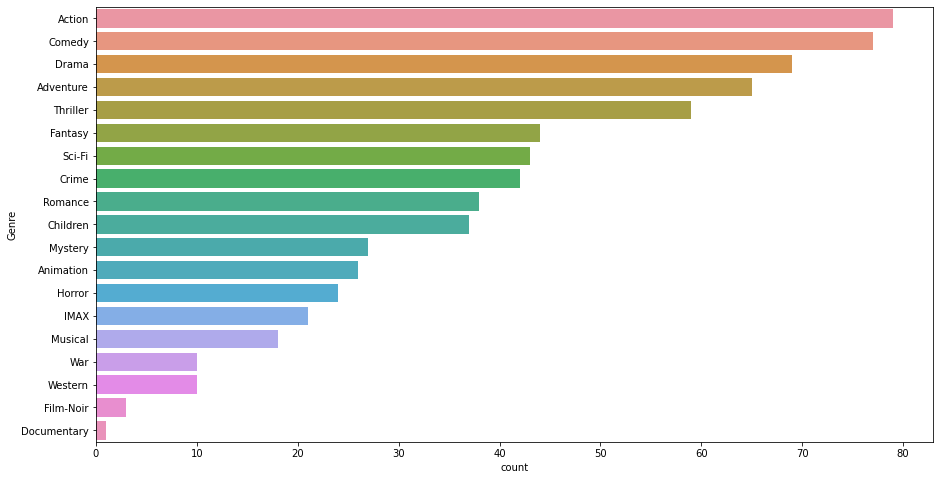

```python
#visualize genre counts
g = genre.nlargest(columns="count", n = 50)
plt.figure(figsize=(15,8))
ax = sns.barplot(data=g, x= "count", y = "genres")
ax.set(ylabel = 'Genre')
plt.show()
```

- **We can see that count of the movies with genre such as Action, Comedy and Drama are maximum**
- **At the same time documentary movies are the least**

### Movies by Year

```python
#Extract year from title column
def find_number(text):
    num = re.findall(r'[0-9]+',text)
    return " ".join(num)
movies['year']=movies['title'].apply(lambda x: find_number(x))
```

```python
#Removing the years from the 'title' column
movies['title'] = movies.title.str.replace('(\(\d\d\d\d\))', '')
#Applying the strip function to get rid of any ending whitespace characters that may have appeared
#movies_df['title'] = movies_df['title'].apply(lambda x: x.strip())
#movies_df.head()
movies.head()
```

[output not shown]

# Approach

### Content Based

- Creating Movie-Genre matrix
- Use of TfIDF vectorizer
- Similarity matrix using Pairwise kernels - to evaluate pairwise distances used linear_kernel which is similar to cosine similarity
- Identifying user preferences
- Find similar movies
- Get user's watched list
- Recommendations

### Collaborative filtering

- Data Preprocessing
- Creating User - Movie matrix
- Finding out similar users based on similarity scores
- Identifying the watched list for target users
- Provide recommendations

# 4.Content Based Movie Recommender System

## Movie-Genre Matrix

Creating a movie-genre matrix by splitting the genres from the movies data. This is done to understand the presence or absence of each genres in the total number of movies ie, 9742. This matrix contains the splitted genres in columns.

- The value 1 represents the presence of a genre in the movie
- The value 0 represents the absence of a genre in the movie

It also helps us know which movies have common genres

```python
genre_list = []                                    #Creating a list to store genres
for genre in movies['genres']:                     #Iterate through the genres column
    genre_split = genre.split('|')                 #Split values from genres column using '|' delimiter
    for item in genre_split:                       #Appending each of the splitted genres in the list created
        if item not in genre_list: genre_list.append(item)

for genre in genre_list:
    movies[genre] = 0                              #Setting initial values to 0

for index,row in movies.iterrows():                #Iteration through the rows in movies data
    for current_genre in genre_list:               #Comparing for every splitted genre in genre_list and the values from genres column
        if current_genre in row['genres']:
            movies.loc[index,current_genre] = 1    #If the genre is present in both then assign 1 as value

movies_sub = movies.iloc[:,4:]
movies_sub.head()
```

|  | Animation | Children | Comedy | Fantasy | Romance | Drama | Action | Crime | Thriller | Horror | Mystery | Sci-Fi | War | Musical | Documentary | IMAX | Western | Film-Noir | (no genres listed) |
| --- | --- | --- | --- | --- | --- | --- | --- | --- | --- | --- | --- | --- | --- | --- | --- | --- | --- | --- | --- |
| 0 | 1 | 1 | 1 | 1 | 0 | 0 | 0 | 0 | 0 | 0 | 0 | 0 | 0 | 0 | 0 | 0 | 0 | 0 | 0 |
| 1 | 0 | 1 | 0 | 1 | 0 | 0 | 0 | 0 | 0 | 0 | 0 | 0 | 0 | 0 | 0 | 0 | 0 | 0 | 0 |
| 2 | 0 | 0 | 1 | 0 | 1 | 0 | 0 | 0 | 0 | 0 | 0 | 0 | 0 | 0 | 0 | 0 | 0 | 0 | 0 |
| 3 | 0 | 0 | 1 | 0 | 1 | 1 | 0 | 0 | 0 | 0 | 0 | 0 | 0 | 0 | 0 | 0 | 0 | 0 | 0 |
| 4 | 0 | 0 | 1 | 0 | 0 | 0 | 0 | 0 | 0 | 0 | 0 | 0 | 0 | 0 | 0 | 0 | 0 | 0 | 0 |

```python
movies_sub.shape
```

```
(9742, 19)
```

```python
movies_list = movies[['movieId','title']]  #Create a dataframe to store movieid and title
movies_list.head()
```

|  | movieId | title |
| --- | --- | --- |
| 0 | 1 | Toy Story (1995) |
| 1 | 2 | Jumanji (1995) |
| 2 | 3 | Grumpier Old Men (1995) |
| 3 | 4 | Waiting to Exhale (1995) |
| 4 | 5 | Father of the Bride Part II (1995) |

## Use of TfIDF Vectorizer

```python
from sklearn.feature_extraction.text import TfidfVectorizer
from sklearn.metrics.pairwise import sigmoid_kernel
from sklearn.metrics.pairwise import linear_kernel
```

TfidfVectorizer transforms text to feature vectors that can be used as input to estimator. This is done to convert the genres to vectors to make them an input for estimating the distances

```python
vectorizer = TfidfVectorizer(analyzer='word',ngram_range=(1, 2),min_df=1)
x = vectorizer.fit_transform(movies['genres'])    #Vectorized values of genres to be used as estimator
```

```python
#checkout TF-IDF scores of genres
df = pd.DataFrame(x[0].T.todense(), index=vectorizer.get_feature_names(), columns=["TF-IDF"])
df = df.sort_values('TF-IDF', ascending=False)
df.head(5)
```

|  | TF-IDF |
| --- | --- |
| comedy fantasy | 0.405143 |
| adventure animation | 0.400886 |
| animation children | 0.383695 |
| children comedy | 0.368188 |
| animation | 0.323359 |

## Similarity matrix using pairwise kernels

Calculating the distance between vectors using pairwise kernels - linear kernel. The sklearn.metrics.pairwise submodule implements utilities to evaluate pairwise distances or affinity of sets of samples.

This module contains both distance metrics and kernels.Kernels are measures of similarity, i.e. s(x1, x2) > s(x1, x3) if objects x1 and x2 are considered “more similar” than objects x1 and x3. A kernel must also be positive semi-definite. The distances between the row vectors of X and the row vectors of Y can be evaluated using pairwise_distances linear_kernel is similar to cosine_similarity but faster.

```python
genre_model = linear_kernel(x, x) #Calculate similarity between the movies
```

```python
genre_model.shape  #This model creates a matrix of similar values in 9742X9742
```

```
(9742, 9742)
```

```python
sig = pd.DataFrame(genre_model) #Create a dataframe for the arrays
```

```python
sig.index = movies['title']    #Set the rows and index of the matrix as movie title
sig.columns = movies['title']
sig.head()
```

| title | Toy Story (1995) | Jumanji (1995) | Grumpier Old Men (1995) | Waiting to Exhale (1995) | Father of the Bride Part II (1995) | Heat (1995) | Sabrina (1995) | Tom and Huck (1995) | Sudden Death (1995) | GoldenEye (1995) | ... | Gintama: The Movie (2010) | anohana: The Flower We Saw That Day - The Movie (2013) | Silver Spoon (2014) | Love Live! The School Idol Movie (2015) | Jon Stewart Has Left the Building (2015) | Black Butler: Book of the Atlantic (2017) | No Game No Life: Zero (2017) | Flint (2017) | Bungo Stray Dogs: Dead Apple (2018) | Andrew Dice Clay: Dice Rules (1991) |
| --- | --- | --- | --- | --- | --- | --- | --- | --- | --- | --- | --- | --- | --- | --- | --- | --- | --- | --- | --- | --- | --- |
| Toy Story (1995) | 1.000000 | 0.313794 | 0.061103 | 0.052711 | 0.167614 | 0.0 | 0.061103 | 0.279004 | 0.0 | 0.090434 | ... | 0.124571 | 0.160186 | 0.076341 | 0.323359 | 0.0 | 0.403736 | 0.497562 | 0.000000 | 0.161232 | 0.167614 |
| Jumanji (1995) | 0.313794 | 1.000000 | 0.000000 | 0.000000 | 0.000000 | 0.0 | 0.000000 | 0.728314 | 0.0 | 0.109266 | ... | 0.000000 | 0.000000 | 0.000000 | 0.000000 | 0.0 | 0.114980 | 0.141701 | 0.000000 | 0.000000 | 0.000000 |
| Grumpier Old Men (1995) | 0.061103 | 0.000000 | 1.000000 | 0.351724 | 0.364546 | 0.0 | 1.000000 | 0.000000 | 0.0 | 0.000000 | ... | 0.057379 | 0.000000 | 0.166036 | 0.000000 | 0.0 | 0.063528 | 0.078291 | 0.000000 | 0.000000 | 0.364546 |
| Waiting to Exhale (1995) | 0.052711 | 0.000000 | 0.351724 | 1.000000 | 0.314480 | 0.0 | 0.351724 | 0.000000 | 0.0 | 0.000000 | ... | 0.049499 | 0.068877 | 0.690467 | 0.000000 | 0.0 | 0.054803 | 0.067539 | 0.290437 | 0.000000 | 0.314480 |
| Father of the Bride Part II (1995) | 0.167614 | 0.000000 | 0.364546 | 0.314480 | 1.000000 | 0.0 | 0.364546 | 0.000000 | 0.0 | 0.000000 | ... | 0.157399 | 0.000000 | 0.455459 | 0.000000 | 0.0 | 0.174265 | 0.214763 | 0.000000 | 0.000000 | 1.000000 |

5 rows × 9742 columns

## Identify User Preferences

Here user preference plays a major role as it is required to suggest similar movies to them. Recommending similar movies based on user's interest will improve the system better and will of user's convenience. For example, if a user has rated the movie Titanic with 5, then the most similar movie to Titanic if not watched by the user has a high chance to be watched when recommended to that user.

Creating a function to identify the top preferred (identified by movies with user's ratings with 4 & 5) movies for the users. This function takes input the userid and top N movies rated 4& 5 by the user. This returns the top N most liked movies for that user.

```python
def most_preferred(userid, top_n):
    high_rated = max(ratings.loc[(ratings.userId==userid),'rating'])  #Assign maximum of rating given by the user
    if high_rated < 4:                                                #If the rating < 4, the movie is not liked by the user
        print('Not likely')
        return(None)
    else:
        movie5 = ratings.loc[(ratings.userId==userid)&(ratings.rating==5),'movieId']  #Movies with rating 5 by the user
        movie4 = ratings.loc[(ratings.userId==userid)&(ratings.rating==4),'movieId']  #Movies with rating 4 by the user

        #If the movies rated 5 exceeds top N we return a random top N movies
        if len(movie5) > top_n:
            return(list(np.random.choice(movie5,top_n)))

        #If the movies rated 4 & 5 together is less than top N, return both lists of movies together
        elif len(movie5) + len(movie4) < top_n:
            return(list(movie5)+list(movie4))

        #Else list all movies rated 5 first then, randomly select movie rated 4 for rest of the top N movies
        else:
            return(list(movie5) + list(np.random.choice(movie4,top_n-len(movie5))))
```

```python
most_preferred(10,10)
```

```
[91529, 7458, 92259, 91529, 92259, 49286, 33794, 8869, 33794, 140110]
```

## Find Similar Movies

For the users top N preferred movies list for all values find similar movies based on their high similarity scores. These similar movies becomes a part of the recommended movies if the user has not watched any of movies from this list.

Create a function with movieid and similarity score as input parameter in order to return the similar movie title for the passed parameter score.

```python
def get_similar_movies(movie_id, sim):

    title = movies_list.loc[movies_list.movieId==movie_id,'title'] #For the given movied return the title of that movie
    title = np.array(title)[0]                                     #To take the specific values

    similarity = sig.loc[title,:]                                  #Similar movies with scores for title and movieid

    scores = np.array(similarity)                                  #Taking out the scores for similar movies obtained

    related = sig.loc[title,:][sig.loc[title,:]>sim].index         #Return movies with only the scores above the passed parameter score

    return(list(related))
```

```python
get_similar_movies(10, 0.70)   #Similar movies for movieid 10 with similarity score > 0.7
```

```
['GoldenEye (1995)',
 'Broken Arrow (1996)',
 'Cliffhanger (1993)',
 'Executive Decision (1996)',
 'Surviving the Game (1994)',
 'Rock, The (1996)',
 'Chain Reaction (1996)',
 'Maximum Risk (1996)',
 'Die Hard 2 (1990)',
 'Anaconda (1997)',
 'Con Air (1997)',
 'Hunt for Red October, The (1990)',
 'Tomorrow Never Dies (1997)',
 'View to a Kill, A (1985)',
 'Rambo: First Blood Part II (1985)',
 'Rambo III (1988)',
 'Goldfinger (1964)',
 'From Russia with Love (1963)',
 'Dr. No (1962)',
 'For Your Eyes Only (1981)',
 'Licence to Kill (1989)',
 'Live and Let Die (1973)',
 'Thunderball (1965)',
 'World Is Not Enough, The (1999)',
 'Mission: Impossible II (2000)',
 'Spy Who Loved Me, The (1977)',
 'Man with the Golden Gun, The (1974)',
 'Diamonds Are Forever (1971)',
 'Living Daylights, The (1987)',
 'Joy Ride (2001)',
 'Ffolkes (1979)',
 'Die Another Day (2002)',
 'Octopussy (1983)',
 'Never Say Never Again (1983)',
 'Delta Force 2 (Delta Force 2: The Colombian Connection) (1990)',
 'Mission: Impossible III (2006)',
 'Poseidon (2006)',
 'Casino Royale (2006)',
 'Quantum of Solace (2008)',
 'Raiders of the Lost Ark: The Adaptation (1989)',
 'Expendables, The (2010)',
 'Mission: Impossible - Ghost Protocol (2011)',
 'Skyfall (2012)',
 'Mission: Impossible - Rogue Nation (2015)',
 'Camino (2016)',
 'Alpha (2018)',
 'Mission: Impossible - Fallout (2018)']
```

## Get User Watched List

Recommending the movies which the user already watched doesn't make sense but this part need to be suggested as 'Watch again' list which the user might watch again if interested. We here need to recommend the user new movies as it brings their interest out to watch more new movies of their interest.

Creating a function to store the watched movie list of the user. This takes input the userid. From the given data we can identify the watched list of a particular user if the user has rated that movie (But it is not mandatory that the user will be rating all of his watched movies) From the ratings done we need to match the user id with given userid which implies the input user has watched that movie. This finally return the movie title of watched list ie, the movies that have been rated.

```python
def user_watched_list(userid):

    #To get the set of movie_ids the user already watched
    #Compare the input userid with ratings.userid if rating is present get that movieid
    index = list(ratings.loc[ratings.userId==userid, 'movieId'].index)

    #From the movieid map the movie title from movies_list data
    return(list(movies_list['title'][index]))
```

```python
user_watched_list(15)  #Watched list of movies for user 15.
```

```
['Chariots of Fire (1981)',
 'Terms of Endearment (1983)',
 'Out of Africa (1985)',
 'Last Emperor, The (1987)',
 'Rain Man (1988)',
 'Driving Miss Daisy (1989)',
 'Take the Money and Run (1969)',
 'Klute (1971)',
 'Repo Man (1984)',
 'Metropolitan (1990)',
 'Labyrinth (1986)',
 'Breakfast Club, The (1985)',
 "Nightmare on Elm Street 2: Freddy's Revenge, A (1985)",
 'Nightmare on Elm Street 3: Dream Warriors, A (1987)',
 'Nightmare on Elm Street 4: The Dream Master, A (1988)',
 'Nightmare on Elm Street 5: The Dream Child, A (1989)',
 "Freddy's Dead: The Final Nightmare (Nightmare on Elm Street Part 6: Freddy's Dead, A) (1991)",
 'Friday the 13th (1980)',
 'Friday the 13th Part 2 (1981)',
 'Friday the 13th Part 3: 3D (1982)',
 'Friday the 13th Part IV: The Final Chapter (1984)',
 'Friday the 13th Part V: A New Beginning (1985)',
 'Friday the 13th Part VI: Jason Lives (1986)',
 'Friday the 13th Part VII: The New Blood (1988)',
 'Friday the 13th Part VIII: Jason Takes Manhattan (1989)',
 'Halloween (1978)',
 'Halloween II (1981)',
 'Halloween III: Season of the Witch (1982)',
 'Halloween 4: The Return of Michael Myers (1988)',
 'Halloween 5: The Revenge of Michael Myers (1989)',
 'Prom Night (1980)',
 'Prom Night IV: Deliver Us From Evil (1992)',
 "Child's Play (1988)",
 "Child's Play 2 (1990)",
 "Child's Play 3 (1991)",
 'Poltergeist (1982)',
 'Poltergeist II: The Other Side (1986)',
 'Poltergeist III (1988)',
 'Exorcist, The (1973)',
 'Exorcist II: The Heretic (1977)',
```

[output cut: 80 more lines]

```
 'Return from Witch Mountain (1978)',
 'Return of Jafar, The (1994)',
 'Return to Oz (1985)',
 'Rocketeer, The (1991)',
 'Shaggy D.A., The (1976)',
 'Sleeping Beauty (1959)',
 'Something Wicked This Way Comes (1983)',
 'Son of Flubber (1963)',
 'Song of the South (1946)',
 'Splash (1984)',
 'Steamboat Willie (1928)',
 'Tall Tale (1995)',
 'Tex (1982)',
 'Tron (1982)',
 'Swing Kids (1993)']
```